# Risk Factor Analysis

## Outcome Variable

**Outcome Variable:** dead0plus

## Predictor Variables

**Intervention Variable:** ever_sunderweight06

**Adjustment Set:**

unadjusted

## Stratifying Variables

The analysis was stratified on these variable(s):

- studyid
- country

## Data Summary

| studyid | country | ever_sunderweight06 | dead0plus | n_cell | n |
| --- | --- | --- | --- | --- | --- |
| Burkina Faso Zn | BURKINA FASO | 0 | 0 | 315 | 338 |
| Burkina Faso Zn | BURKINA FASO | 0 | 1 | 2 | 338 |
| Burkina Faso Zn | BURKINA FASO | 1 | 0 | 21 | 338 |
| Burkina Faso Zn | BURKINA FASO | 1 | 1 | 0 | 338 |
| EE | PAKISTAN | 0 | 0 | 218 | 380 |
| EE | PAKISTAN | 0 | 1 | 1 | 380 |
| EE | PAKISTAN | 1 | 0 | 158 | 380 |
| EE | PAKISTAN | 1 | 1 | 3 | 380 |
| GMS-Nepal | NEPAL | 0 | 0 | 600 | 697 |
| GMS-Nepal | NEPAL | 0 | 1 | 3 | 697 |
| GMS-Nepal | NEPAL | 1 | 0 | 90 | 697 |
| GMS-Nepal | NEPAL | 1 | 1 | 4 | 697 |
| iLiNS-DOSE | MALAWI | 0 | 0 | 1646 | 1816 |
| iLiNS-DOSE | MALAWI | 0 | 1 | 106 | 1816 |
| iLiNS-DOSE | MALAWI | 1 | 0 | 56 | 1816 |
| iLiNS-DOSE | MALAWI | 1 | 1 | 8 | 1816 |
| iLiNS-DYAD-M | MALAWI | 0 | 0 | 1080 | 1202 |
| iLiNS-DYAD-M | MALAWI | 0 | 1 | 30 | 1202 |
| iLiNS-DYAD-M | MALAWI | 1 | 0 | 78 | 1202 |
| iLiNS-DYAD-M | MALAWI | 1 | 1 | 14 | 1202 |
| JiVitA-3 | BANGLADESH | 0 | 0 | 22216 | 27237 |
| JiVitA-3 | BANGLADESH | 0 | 1 | 436 | 27237 |
| JiVitA-3 | BANGLADESH | 1 | 0 | 4155 | 27237 |
| JiVitA-3 | BANGLADESH | 1 | 1 | 430 | 27237 |
| JiVitA-4 | BANGLADESH | 0 | 0 | 4716 | 5276 |
| JiVitA-4 | BANGLADESH | 0 | 1 | 32 | 5276 |
| JiVitA-4 | BANGLADESH | 1 | 0 | 512 | 5276 |
| JiVitA-4 | BANGLADESH | 1 | 1 | 16 | 5276 |
| Keneba | GAMBIA | 0 | 0 | 2379 | 2632 |
| Keneba | GAMBIA | 0 | 1 | 71 | 2632 |
| Keneba | GAMBIA | 1 | 0 | 158 | 2632 |
| Keneba | GAMBIA | 1 | 1 | 24 | 2632 |
| MAL-ED | BANGLADESH | 0 | 0 | 243 | 265 |
| MAL-ED | BANGLADESH | 0 | 1 | 2 | 265 |
| MAL-ED | BANGLADESH | 1 | 0 | 19 | 265 |
| MAL-ED | BANGLADESH | 1 | 1 | 1 | 265 |
| MAL-ED | INDIA | 0 | 0 | 217 | 251 |
| MAL-ED | INDIA | 0 | 1 | 1 | 251 |
| MAL-ED | INDIA | 1 | 0 | 32 | 251 |
| MAL-ED | INDIA | 1 | 1 | 1 | 251 |
| MAL-ED | PERU | 0 | 0 | 290 | 303 |
| MAL-ED | PERU | 0 | 1 | 2 | 303 |
| MAL-ED | PERU | 1 | 0 | 11 | 303 |
| MAL-ED | PERU | 1 | 1 | 0 | 303 |
| MAL-ED | SOUTH AFRICA | 0 | 0 | 300 | 314 |
| MAL-ED | SOUTH AFRICA | 0 | 1 | 0 | 314 |
| MAL-ED | SOUTH AFRICA | 1 | 0 | 13 | 314 |
| MAL-ED | SOUTH AFRICA | 1 | 1 | 1 | 314 |
| MAL-ED | TANZANIA, UNITED REPUBLIC OF | 0 | 0 | 251 | 262 |
| MAL-ED | TANZANIA, UNITED REPUBLIC OF | 0 | 1 | 2 | 262 |
| MAL-ED | TANZANIA, UNITED REPUBLIC OF | 1 | 0 | 8 | 262 |
| MAL-ED | TANZANIA, UNITED REPUBLIC OF | 1 | 1 | 1 | 262 |
| PROVIDE | BANGLADESH | 0 | 0 | 647 | 700 |
| PROVIDE | BANGLADESH | 0 | 1 | 5 | 700 |
| PROVIDE | BANGLADESH | 1 | 0 | 48 | 700 |
| PROVIDE | BANGLADESH | 1 | 1 | 0 | 700 |
| SAS-CompFeed | INDIA | 0 | 0 | 1247 | 1533 |
| SAS-CompFeed | INDIA | 0 | 1 | 26 | 1533 |
| SAS-CompFeed | INDIA | 1 | 0 | 236 | 1533 |
| SAS-CompFeed | INDIA | 1 | 1 | 24 | 1533 |
| SAS-FoodSuppl | INDIA | 0 | 0 | 304 | 416 |
| SAS-FoodSuppl | INDIA | 0 | 1 | 2 | 416 |
| SAS-FoodSuppl | INDIA | 1 | 0 | 106 | 416 |
| SAS-FoodSuppl | INDIA | 1 | 1 | 4 | 416 |
| TanzaniaChild2 | TANZANIA, UNITED REPUBLIC OF | 0 | 0 | 2325 | 2396 |
| TanzaniaChild2 | TANZANIA, UNITED REPUBLIC OF | 0 | 1 | 1 | 2396 |
| TanzaniaChild2 | TANZANIA, UNITED REPUBLIC OF | 1 | 0 | 70 | 2396 |
| TanzaniaChild2 | TANZANIA, UNITED REPUBLIC OF | 1 | 1 | 0 | 2396 |
| VITAMIN-A | INDIA | 0 | 0 | 2858 | 3906 |
| VITAMIN-A | INDIA | 0 | 1 | 30 | 3906 |
| VITAMIN-A | INDIA | 1 | 0 | 970 | 3906 |
| VITAMIN-A | INDIA | 1 | 1 | 48 | 3906 |
| ZVITAMBO | ZIMBABWE | 0 | 0 | 12411 | 14085 |
| ZVITAMBO | ZIMBABWE | 0 | 1 | 816 | 14085 |
| ZVITAMBO | ZIMBABWE | 1 | 0 | 556 | 14085 |
| ZVITAMBO | ZIMBABWE | 1 | 1 | 302 | 14085 |

The following strata were considered:

- studyid: Burkina Faso Zn, country: BURKINA FASO
- studyid: EE, country: PAKISTAN
- studyid: GMS-Nepal, country: NEPAL
- studyid: iLiNS-DOSE, country: MALAWI
- studyid: iLiNS-DYAD-M, country: MALAWI
- studyid: JiVitA-3, country: BANGLADESH
- studyid: JiVitA-4, country: BANGLADESH
- studyid: Keneba, country: GAMBIA
- studyid: MAL-ED, country: BANGLADESH
- studyid: MAL-ED, country: INDIA
- studyid: MAL-ED, country: PERU
- studyid: MAL-ED, country: SOUTH AFRICA
- studyid: MAL-ED, country: TANZANIA, UNITED REPUBLIC OF
- studyid: PROVIDE, country: BANGLADESH
- studyid: SAS-CompFeed, country: INDIA
- studyid: SAS-FoodSuppl, country: INDIA
- studyid: TanzaniaChild2, country: TANZANIA, UNITED REPUBLIC OF
- studyid: VITAMIN-A, country: INDIA
- studyid: ZVITAMBO, country: ZIMBABWE

### Dropped Strata

Some strata were dropped due to rare outcomes:

- studyid: Burkina Faso Zn, country: BURKINA FASO
- studyid: EE, country: PAKISTAN
- studyid: GMS-Nepal, country: NEPAL
- studyid: MAL-ED, country: BANGLADESH
- studyid: MAL-ED, country: INDIA
- studyid: MAL-ED, country: PERU
- studyid: MAL-ED, country: SOUTH AFRICA
- studyid: MAL-ED, country: TANZANIA, UNITED REPUBLIC OF
- studyid: PROVIDE, country: BANGLADESH
- studyid: SAS-FoodSuppl, country: INDIA
- studyid: TanzaniaChild2, country: TANZANIA, UNITED REPUBLIC OF

## Methods Detail

We’re interested in the causal parameters $E[Y_a]$ for all values of $a \in \mathcal{A}$. These parameters represent the mean outcome if, possibly contrary to fact, we intervened to set all units to have $A=a$. Under the randomization and positivity assumptions, these are identified by the statistical parameters $\psi_a=E_W[E_{Y|A,W}(Y|A=a,W)]$. In addition, we’re interested in the mean of $Y$, $E[Y]$ under no intervention (the observed mean). We will estimate these parameters by using SuperLearner to fit the relevant likelihood factors – $E_{Y|A,W}(Y|A=a,W)$ and $p(A=a|W)$, and then updating our likelihood fit using a joint TMLE.

For unadjusted analyses ($W=\{\}$), initial likelihoods were estimated using Lrnr_glm to estimate the simple $E(Y|A)$ and Lrnr_mean to estimate $p(A)$. For adjusted analyses, a small library containing Lrnr_glmnet, Lrnr_xgboost, and Lrnr_mean was used.

Having estimated these parameters, we will then use the delta method to estimate relative risks and attributable risks relative to a prespecified baseline level of $A$.

# Results Detail

## Results Plots

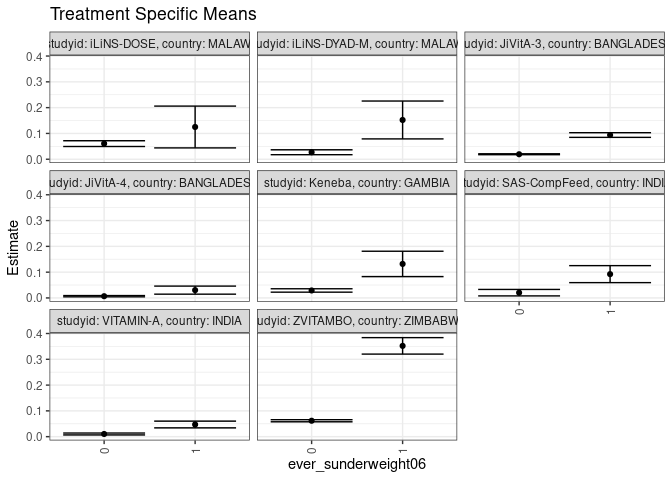

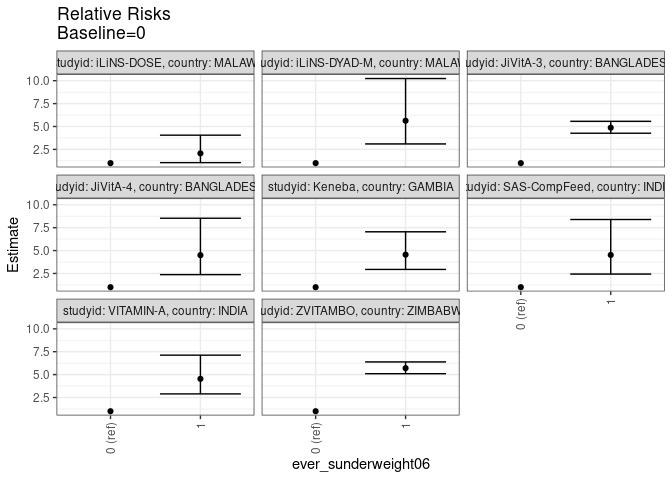

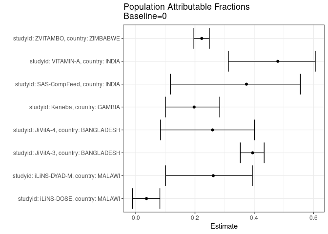

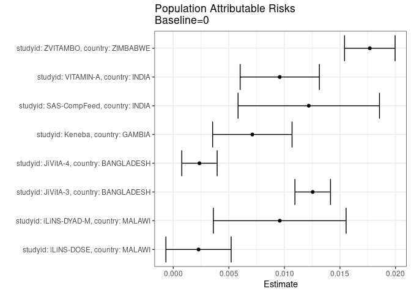

## Results Table

### Parameter: TSM

| studyid | country | intervention_level | baseline_level | estimate | ci_lower | ci_upper |
| --- | --- | --- | --- | --- | --- | --- |
| iLiNS-DOSE | MALAWI | 0 | NA | 0.0605023 | 0.0493353 | 0.0716692 |
| iLiNS-DOSE | MALAWI | 1 | NA | 0.1250000 | 0.0439530 | 0.2060470 |
| iLiNS-DYAD-M | MALAWI | 0 | NA | 0.0270270 | 0.0174833 | 0.0365707 |
| iLiNS-DYAD-M | MALAWI | 1 | NA | 0.1521739 | 0.0787465 | 0.2256014 |
| JiVitA-3 | BANGLADESH | 0 | NA | 0.0192477 | 0.0174699 | 0.0210256 |
| JiVitA-3 | BANGLADESH | 1 | NA | 0.0937841 | 0.0847066 | 0.1028615 |
| JiVitA-4 | BANGLADESH | 0 | NA | 0.0067397 | 0.0042344 | 0.0092450 |
| JiVitA-4 | BANGLADESH | 1 | NA | 0.0303030 | 0.0146059 | 0.0460001 |
| Keneba | GAMBIA | 0 | NA | 0.0289796 | 0.0223359 | 0.0356233 |
| Keneba | GAMBIA | 1 | NA | 0.1318681 | 0.0827029 | 0.1810333 |
| SAS-CompFeed | INDIA | 0 | NA | 0.0204242 | 0.0079449 | 0.0329035 |
| SAS-CompFeed | INDIA | 1 | NA | 0.0923077 | 0.0593946 | 0.1252208 |
| VITAMIN-A | INDIA | 0 | NA | 0.0103878 | 0.0066895 | 0.0140861 |
| VITAMIN-A | INDIA | 1 | NA | 0.0471513 | 0.0341290 | 0.0601736 |
| ZVITAMBO | ZIMBABWE | 0 | NA | 0.0616920 | 0.0575917 | 0.0657923 |
| ZVITAMBO | ZIMBABWE | 1 | NA | 0.3519814 | 0.3200238 | 0.3839389 |

### Parameter: E(Y)

| studyid | country | intervention_level | baseline_level | estimate | ci_lower | ci_upper |
| --- | --- | --- | --- | --- | --- | --- |
| iLiNS-DOSE | MALAWI | NA | NA | 0.0627753 | 0.0516163 | 0.0739344 |
| iLiNS-DYAD-M | MALAWI | NA | NA | 0.0366057 | 0.0259850 | 0.0472263 |
| JiVitA-3 | BANGLADESH | NA | NA | 0.0317950 | 0.0295928 | 0.0339972 |
| JiVitA-4 | BANGLADESH | NA | NA | 0.0090978 | 0.0063582 | 0.0118374 |
| Keneba | GAMBIA | NA | NA | 0.0360942 | 0.0289669 | 0.0432215 |
| SAS-CompFeed | INDIA | NA | NA | 0.0326158 | 0.0204960 | 0.0447355 |
| VITAMIN-A | INDIA | NA | NA | 0.0199693 | 0.0155816 | 0.0243570 |
| ZVITAMBO | ZIMBABWE | NA | NA | 0.0793752 | 0.0749108 | 0.0838397 |

### Parameter: RR

| studyid | country | intervention_level | baseline_level | estimate | ci_lower | ci_upper |
| --- | --- | --- | --- | --- | --- | --- |
| iLiNS-DOSE | MALAWI | 0 | 0 | 1.000000 | 1.000000 | 1.000000 |
| iLiNS-DOSE | MALAWI | 1 | 0 | 2.066038 | 1.052847 | 4.054256 |
| iLiNS-DYAD-M | MALAWI | 0 | 0 | 1.000000 | 1.000000 | 1.000000 |
| iLiNS-DYAD-M | MALAWI | 1 | 0 | 5.630435 | 3.096451 | 10.238106 |
| JiVitA-3 | BANGLADESH | 0 | 0 | 1.000000 | 1.000000 | 1.000000 |
| JiVitA-3 | BANGLADESH | 1 | 0 | 4.872470 | 4.267010 | 5.563841 |
| JiVitA-4 | BANGLADESH | 0 | 0 | 1.000000 | 1.000000 | 1.000000 |
| JiVitA-4 | BANGLADESH | 1 | 0 | 4.496212 | 2.370617 | 8.527707 |
| Keneba | GAMBIA | 0 | 0 | 1.000000 | 1.000000 | 1.000000 |
| Keneba | GAMBIA | 1 | 0 | 4.550379 | 2.937417 | 7.049034 |
| SAS-CompFeed | INDIA | 0 | 0 | 1.000000 | 1.000000 | 1.000000 |
| SAS-CompFeed | INDIA | 1 | 0 | 4.519527 | 2.433539 | 8.393587 |
| VITAMIN-A | INDIA | 0 | 0 | 1.000000 | 1.000000 | 1.000000 |
| VITAMIN-A | INDIA | 1 | 0 | 4.539096 | 2.892561 | 7.122889 |
| ZVITAMBO | ZIMBABWE | 0 | 0 | 1.000000 | 1.000000 | 1.000000 |
| ZVITAMBO | ZIMBABWE | 1 | 0 | 5.705462 | 5.098279 | 6.384959 |

### Parameter: PAR

| studyid | country | intervention_level | baseline_level | estimate | ci_lower | ci_upper |
| --- | --- | --- | --- | --- | --- | --- |
| iLiNS-DOSE | MALAWI | 0 | NA | 0.0022730 | -0.0006617 | 0.0052078 |
| iLiNS-DYAD-M | MALAWI | 0 | NA | 0.0095786 | 0.0036071 | 0.0155502 |
| JiVitA-3 | BANGLADESH | 0 | NA | 0.0125472 | 0.0109462 | 0.0141483 |
| JiVitA-4 | BANGLADESH | 0 | NA | 0.0023581 | 0.0007662 | 0.0039500 |
| Keneba | GAMBIA | 0 | NA | 0.0071146 | 0.0035420 | 0.0106873 |
| SAS-CompFeed | INDIA | 0 | NA | 0.0121916 | 0.0058295 | 0.0185537 |
| VITAMIN-A | INDIA | 0 | NA | 0.0095815 | 0.0060172 | 0.0131457 |
| ZVITAMBO | ZIMBABWE | 0 | NA | 0.0176832 | 0.0154101 | 0.0199563 |

### Parameter: PAF

| studyid | country | intervention_level | baseline_level | estimate | ci_lower | ci_upper |
| --- | --- | --- | --- | --- | --- | --- |
| iLiNS-DOSE | MALAWI | 0 | NA | 0.0362092 | -0.0112860 | 0.0814739 |
| iLiNS-DYAD-M | MALAWI | 0 | NA | 0.2616708 | 0.1008386 | 0.3937350 |
| JiVitA-3 | BANGLADESH | 0 | NA | 0.3946294 | 0.3529744 | 0.4336027 |
| JiVitA-4 | BANGLADESH | 0 | NA | 0.2591969 | 0.0832377 | 0.4013832 |
| Keneba | GAMBIA | 0 | NA | 0.1971128 | 0.1001870 | 0.2835979 |
| SAS-CompFeed | INDIA | 0 | NA | 0.3737942 | 0.1172654 | 0.5557739 |
| VITAMIN-A | INDIA | 0 | NA | 0.4798104 | 0.3127948 | 0.6062351 |
| ZVITAMBO | ZIMBABWE | 0 | NA | 0.2227802 | 0.1961793 | 0.2485008 |